# Отчёт по прохождению 2 этапа внешнего курса

Работа с серверами

Автор

принадлежность

Терентеевская Светлана Александровна, Student

Российский университет дружбы народов

Дата публикации

2026-05-10

# Информация

## Докладчик

- Терентеевская Светлана Александровна
- Группа НКАбд-05-25, студент бакалавра
- Российский университет дружбы народов им. П. Лумумбы
- 1032253498@rudn.ru
- https://github.com/SvetlanaTerenteevskaya

# Вводная часть

## Цель работы

Пройти 2 этапа курса “Введение в Linux” на платформе Stepik и ознакомиться с функционалом Linux.

## Задание

Просмотреть видео и на основе полученной информации пройти тестовые и интерактивнные задания.

## Теоретическое введение

Линукс - в части случаев GNU/Linux — семейство Unix-подобных операционных систем на базе ядра Linux, включающих тот или иной набор утилит и программ проекта GNU, и, возможно, другие компоненты. Как и ядро Linux, системы на его основе, как правило, создаются и распространяются в соответствии с моделью разработки свободного и открытого программного обеспечения. Linux-системы распространяются в основном бесплатно в виде различных дистрибутивов — в форме, готовой для установки и удобной для сопровождения и обновлений, — и имеющих свой набор системных и прикладных компонентов, как свободных, так и проприетарных.

# Прохождение внешнего курса

Удаленный сервер - это компьютер, который находится в дата-центре, а доступ к нему можно получить через Интернет. Он позволяет хранить общедоступные данные, конфиденциальные данные. Также может выполнять затратные по времени и памяти вычисления и хранить большие объемы данных (рис. 1).

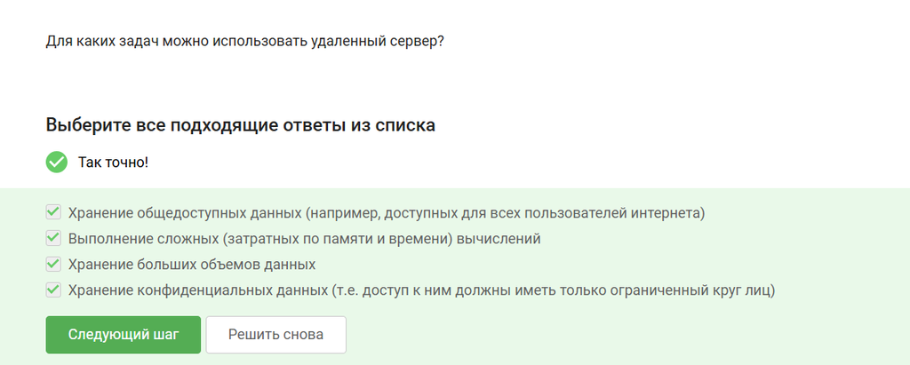

Рисунок 1: 1 задание

Только id_rsa.pub, потому что он является открытым (рис. 2).

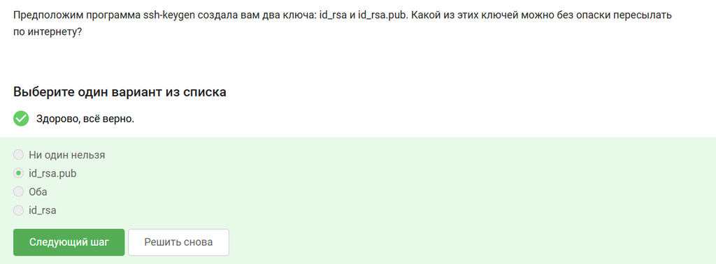

Рисунок 2: 2 задание

-r рекурсивно копирует все папки и подпапки (рис. 3).

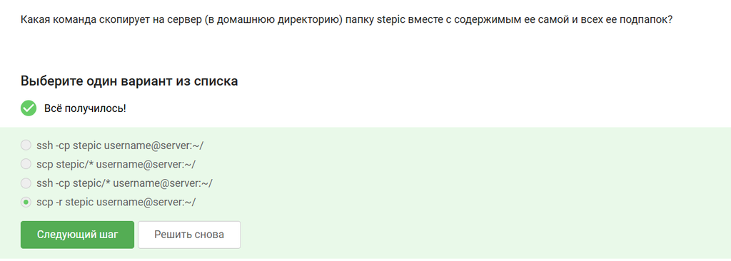

Рисунок 3: 3 задание

Необходимо проверить интернет соединения, чтоб понять, может ли устройство соединиться с сервером, а затем проверить, знает ли оно вообще о существовании такой программы (рис. 4).

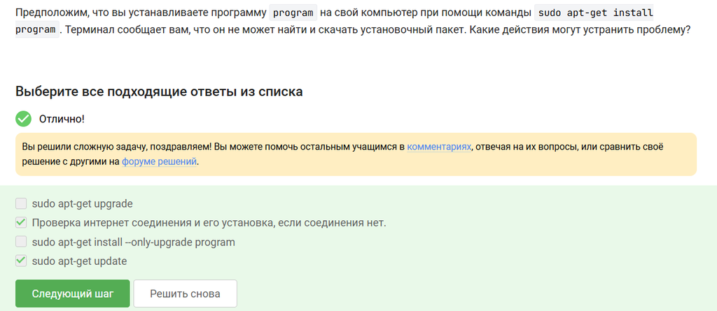

Рисунок 4: 4 задание

Filezilla - FTP/SFTP-клиент и его главная задача - передавать файлы в обе стороны, также он показывает удаленную файловую систему как обычный файловый менеджер и работает только с файлами, а не с выполнением программ на сервере (рис. 5).

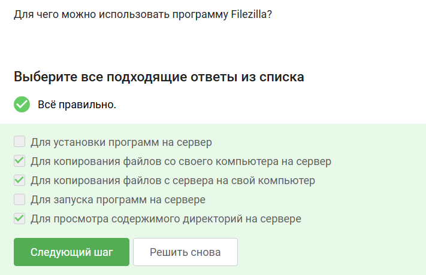

Рисунок 5: 5 задание

Запуск программы на своем компьютере не решит проблему “запуск программы на сервере”, поэтому необходимо настроить сервер, чтоб он поддерживал вывод информации на экран компьютера и проверить, есть ли другая версия этой программы (рис. 6).

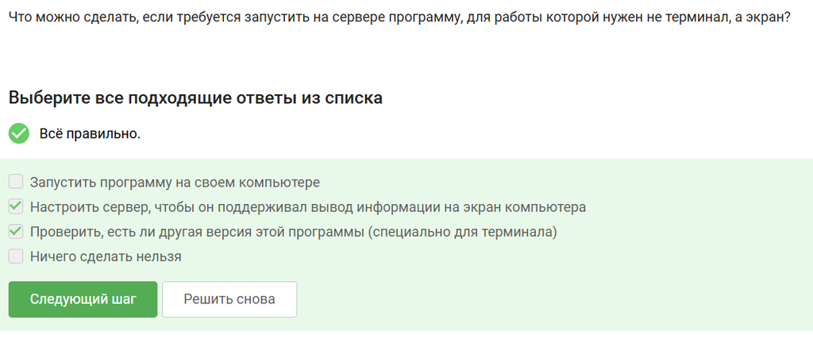

Рисунок 6: 6 задание

Все варинаты кроме program ?! верны. Не существует такой команды program ?! (рис. 7).

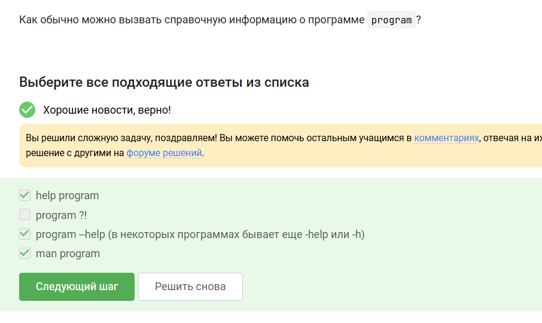

Рисунок 7: 7 задание

Из справки программы FastQC следует, что она принимает форматы: bam, sam, bam_mapped, sam_mapped, fastq. Остальные не поддерживаются, а fastqc-это название программы, а не формат (рис. 8).

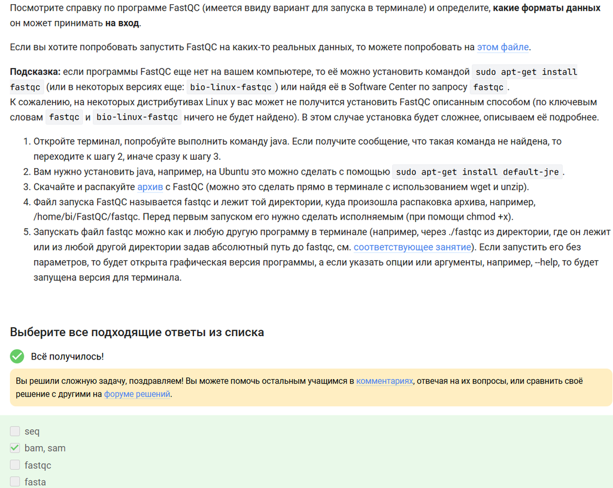

Рисунок 8: 8 задание

-infile=test.fasta - указывает входной файл. -align - опция, которая явно запускает множественное выравнивание (рис. 9).

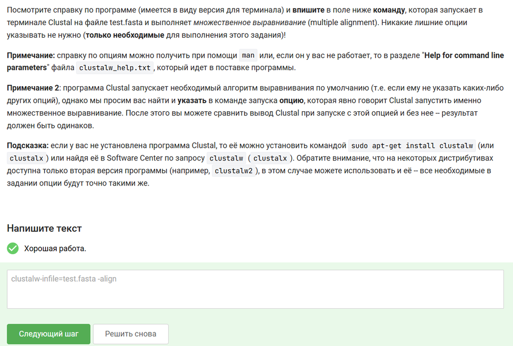

Рисунок 9: 9 задание

Ctrl+C завершает процесс, а Ctrl+Z приостанавливает (рис. 10).

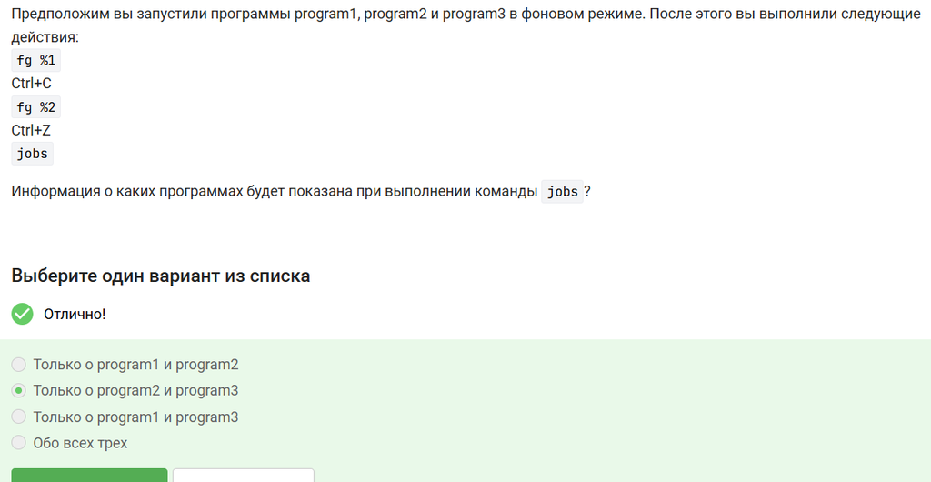

Рисунок 10: 10 задание

ps и top показывают PID, jobs - номер задачи, который не совпадает с PID (рис. 11).

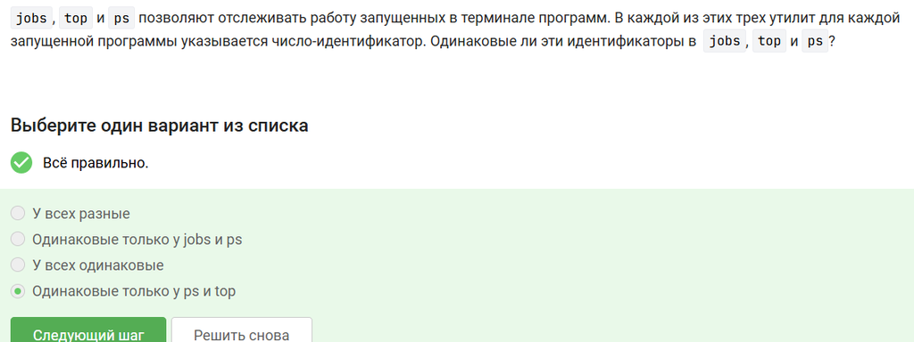

Рисунок 11: 11 задание

При kill -9 ядро мгновенно завершает процесс без возможности игнорирования. kill -18 продолжает остановленный процесс, а просто kill процесс может его перехватить или завершиться “мягко” (рис. 12).

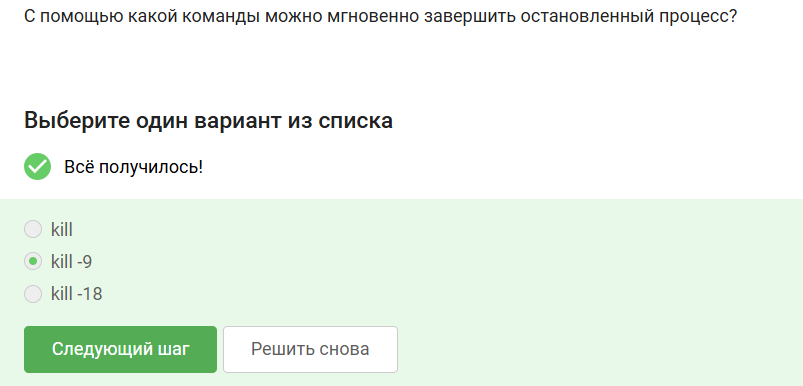

Рисунок 12: 12 задание

Приостановленный процесс не получает сигналы, пока не будет продолжен, после kill процесс останется остановленным. А когда его продолжат он начнет завершаться (рис. 13).

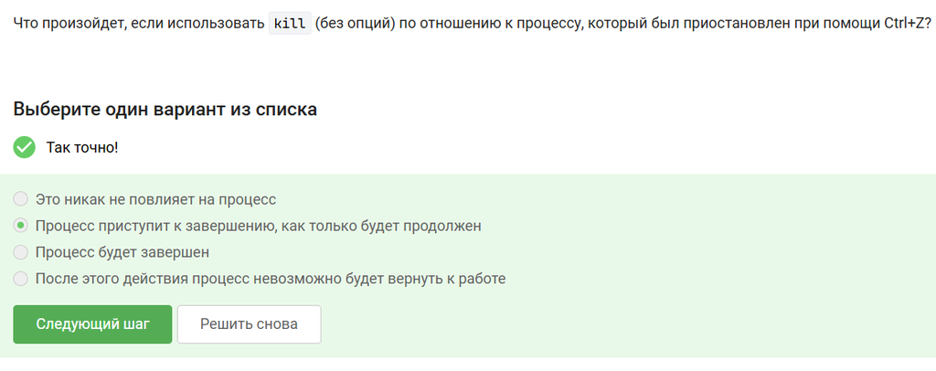

Рисунок 13: 13 задание

Запущенная программа потребляет ресурсы CPU, а остановленная нет (рис. 14).

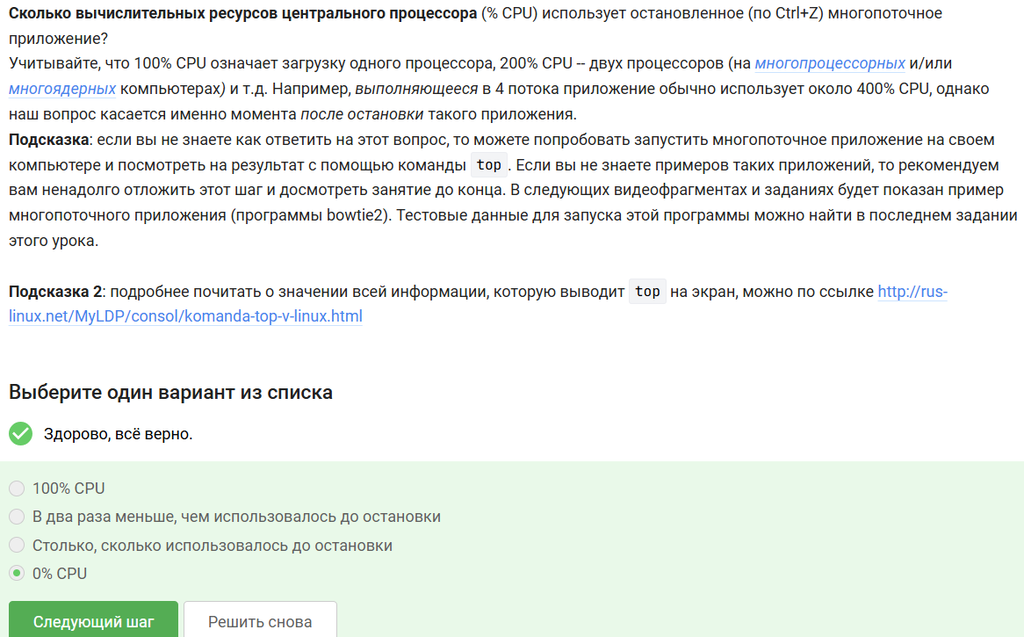

Рисунок 14: 14 задание

Приостановленное приложение не выполняет новых действий, поэтому не занимает вычислительные ресурсы компьютера (CPU 0%). При этом, в оперативной памяти оно сохранится, поэтому оно будет занимать столько же оперативной памяти, сколько до постановки на паузу (рис. 15).

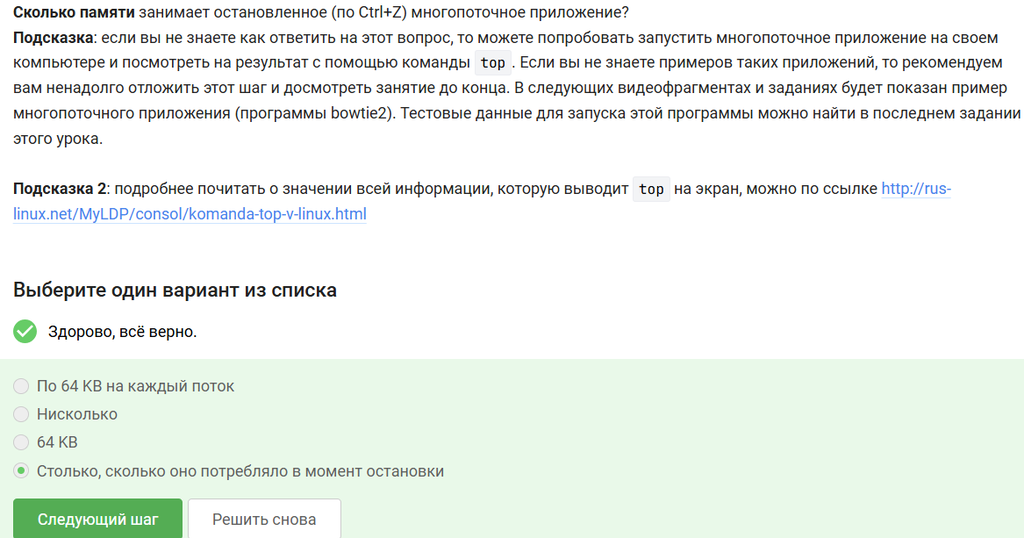

Рисунок 15: 15 задание

Завершить один из потоков запущенного многопоточного приложения никак нельзя (рис. 16).

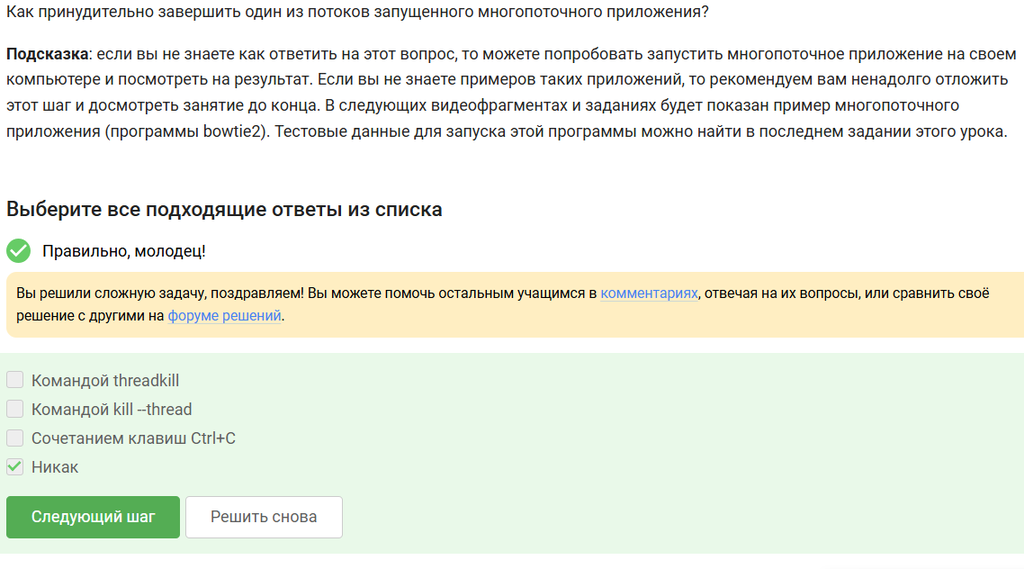

Рисунок 16: 16 задание

Только bowtie2 можно выполнить в несколько потоков (рис. 17).

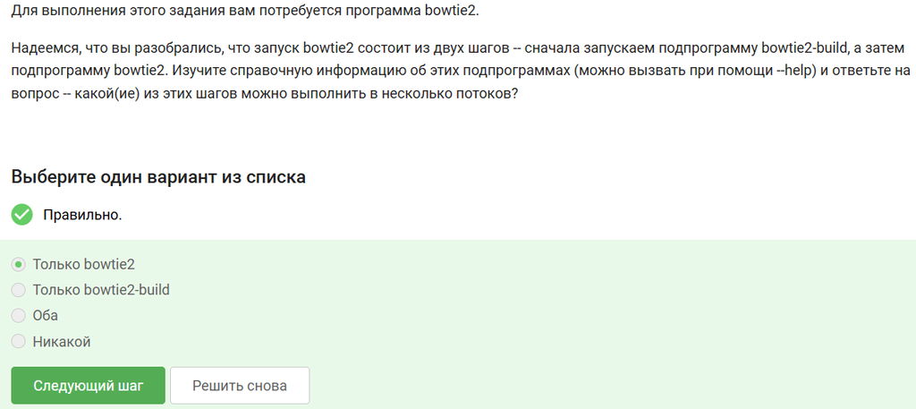

Рисунок 17: 17 задание

Я скачала необходимые для запуска bowtie2 файлы, запустила программу bowtie (рис. 18).

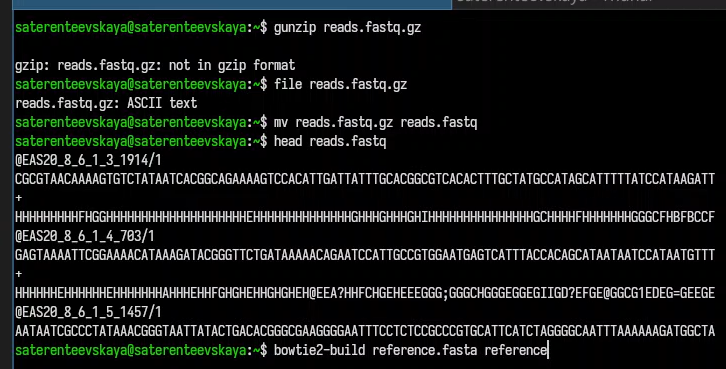

Рисунок 18: 18 задание

Записала данные в файл (рис. 19).

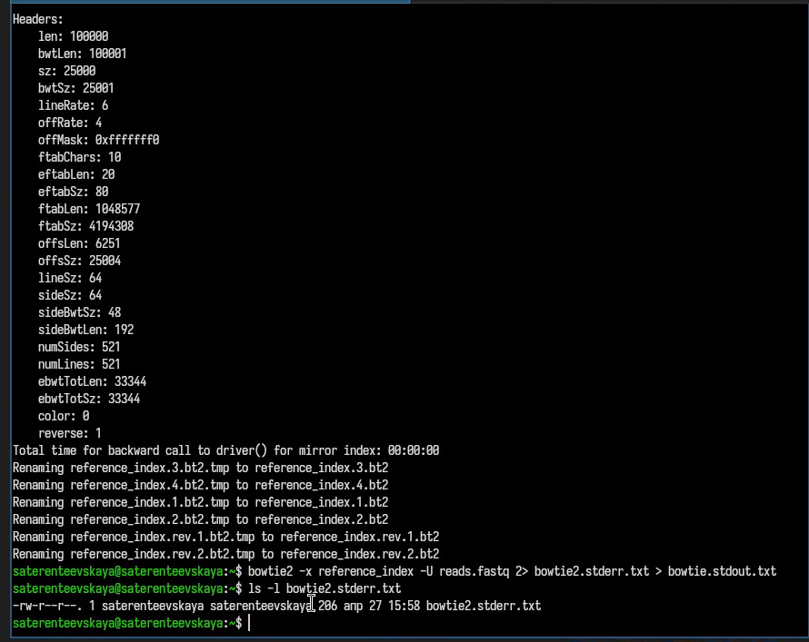

Рисунок 19: 18 задание

Вставила в форму на степике (рис. 20).

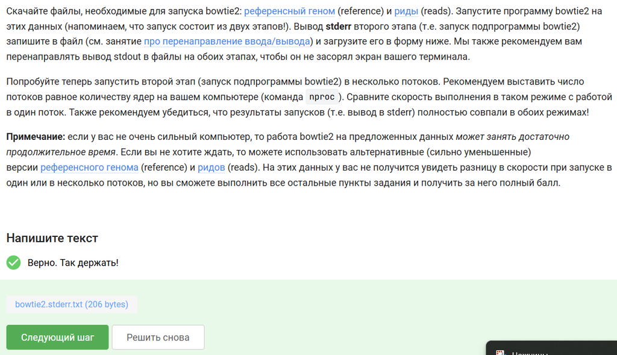

Рисунок 20: 18 задание

fg работает только в той оболочке, где процесс был запущен и остановлен. Во второй вкладке - другой экземпляр оболочки, у него нет доступа к списку задач первой вкладки, поэтому терминал сообщит, что нет процесса для fg (рис. 21).

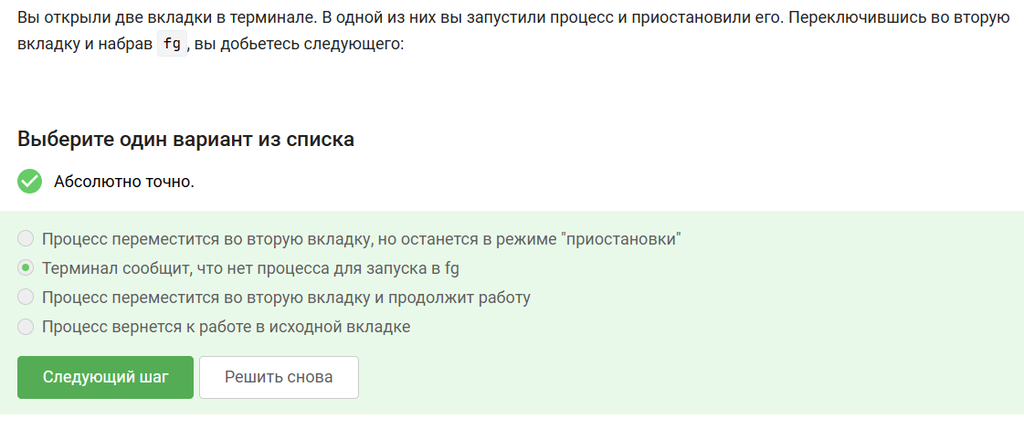

Рисунок 21: 19 задание

exit завершает работу tmux (рис. 22).

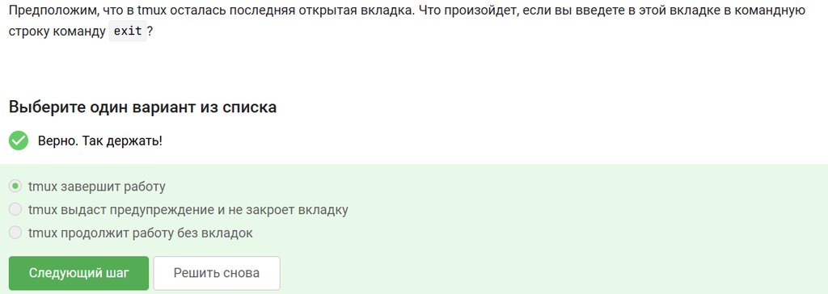

Рисунок 22: 20 задание

Мы заходили на сервер с терминала, который и закрыли, а tmux будет продолжать свою работу на сервере (рис. 23).

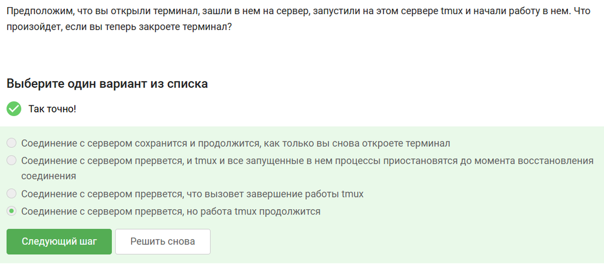

Рисунок 23: 21 задание

Ещё будет предупреждение о том, что работа завершится. Запущенный процесс во вкладке, конечно же, при её закрытии, пропадёт (рис. 24).

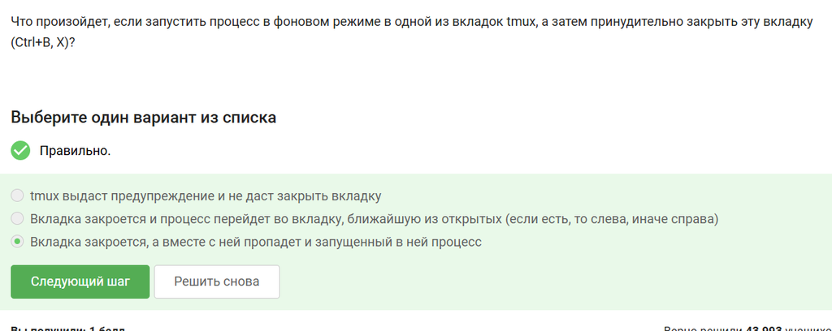

Рисунок 24: 22 задание

За переименование текущей вкладки отвечает Ctrl+B и запятая (рис. 25).

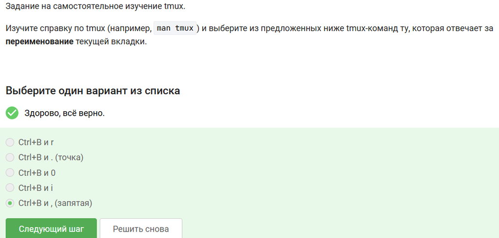

Рисунок 25: 23 задание

Ctrl+b c - создать новое окно;

Ctrl+b w - выбрать окно из списка;

Ctrl+b 0-9 - открыть окно по его номеру;

Ctrl+b , - переименовать текущее окно;

Ctrl+b % - разделить текущую панель по горизонтали;

Ctrl+b ” - разделить текущую панель по вертикали;

Ctrl+b стрелка - перейти на панель, находящуюся в стороне, куда указывает стрелка;

Ctrl+b Ctrl+стрелка - изменить размер текущей панели;

Ctrl+b o - перейти на следующую панель;

Ctrl+b ; - переключаться между текущей и предыдущей панелью;

Ctrl+b x - закрыть текущую панель;

Ctrl+b [ - войти в режим копирования (подробнее ниже);

Ctrl+b ] - вставить из внутреннего буфера обмена tmux;

Ctrl+b d - отключится от текущей сессии;

Ctrl+b : - открыть командную строку.

Можно закрыть одно из делений вкладки выполнив команды Ctrl+B и Х, по половинам “разделенной” вкладки можно перемещаться при помощи Ctrl+B и стрелок - как описано в задании выше, делить экран можно только в текущей вкладке tmux, а не во всех вкладках одновременно (рис. 26).

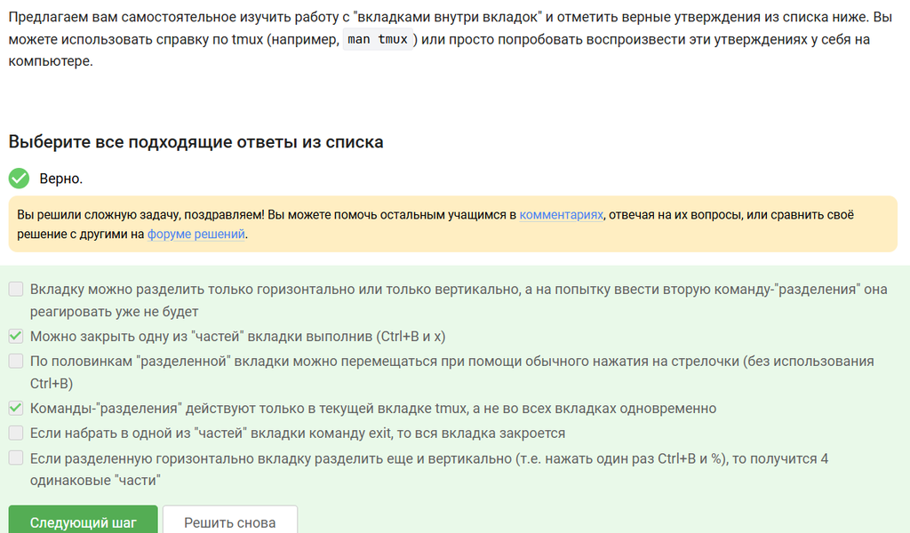

Рисунок 26: 24 задание

# Выводы

Я прошла 2 этап курса “Введение в Linux” на платформе Stepik ознакомилась с функционалом операционной системы Linux.

# Список литературы

[Введение в Linux](https://stepik.org/course/73/syllabus)